# R Notebook

```r
include <- function(library_name){
  if( !(library_name %in% installed.packages()) )
    install.packages(library_name)
  library(library_name, character.only=TRUE)
}
include("tidyverse")
include("rvest")
include("tidyr")
include("knitr")
#purl("deliverable1.Rmd", output = "part1.r")
source("part1.r")
```

# Introduction:

# Getting data:

I am going to use several html functions to bring in the table data. The table data is read into values and values 2. I will then split the data up by state to organize the data.

```r
html <- read_html("https://nces.ed.gov/programs/digest/d17/tables/dt17_211.60.asp")

values <- html %>%
              html_nodes("td.TblCls008") %>%
              html_text()

values2 <- html %>%
            html_nodes("td.TblCls003") %>%
            html_text()

United_States <- values2[1:15]
United_States <- gsub("[$]", "", United_States)
Alabama <- values[1:15]
Alaska <- values[16:30]
Arizona <- values[31:45]
Arkansas <- values[46:60]
California <- values[61:75]
Colorado     <- values[89:103]
Connecticut  <- values[104:118]
Delaware  <- values[119:133]
District_of_Columbia  <- values[149:163]
Florida  <- values[164:178]
Georgia <- values[192:206]
Hawaii <- values[207:221]
Idaho   <- values[222:236]
Illinois <- values[237:251]
Indiana <- values[252:266]
Iowa <- values[280:294]
Kansas <- values[295:309]
Kentucky <- values[310:324]
Louisiana   <- values[325:339]
Maine   <- values[340:354]
Maryland <- values[368:382]
Massachusetts   <- values[383:397]
Michigan <- values[398:412]
Minnesota    <- values[413:427]
Mississippi <- values[428:442]
Missouri <- values[456:470]
Montana <- values[471:485]
Nebraska <- values[486:500]
Nevada <- values[501:515]
New_Hampshire   <- values[516:530]
New_Jersey <- values[544:558]
New_Mexico <- values[559:573]
New_York <- values[574:588]
North_Carolina <- values[589:603]
North_Dakota <- values[604:618]
Ohio <- values[632:646]
Oklahoma <- values[647:661]
Oregon <- values[662:676]
Pennsylvania <- values[677:691]
Rhode_Island <- values[692:706]
South_Carolina <- values[720:734]
South_Dakota <- values[735:749]
Tennessee   <- values[750:764]
Texas <- values[765:779]
Utah <- values[780:794]
Vermont <- values[808:822]
Virginia <- values[823:837]
Washington <- values[838:852]
West_Virginia <- values[853:867]
Wisconsin <- values[868:882]
Wyoming <- values2[16:30]
```

# Cleaning the new data:

After organizing the table data I will create a vector to hold the different categories. With that I will create a table to hold all of the data brought in from the website.

```r
Categories <- c("Current_Dollars:1969-70",  "Current_Dollars:1979-80",  "Current_Dollars:1989-90",  "Current_Dollars:1999-2000",    "Current_Dollars:2009-10",  "Current_Dollars:2015-16",  "Current_Dollars:2016-17",  "Constant_2016-17_dollars:1969-70", "Constant_2016-17_dollars:1979-80", "Constant_2016-17_dollars:1989-90", "Constant_2016-17_dollars:1999-2000",   "Constant_2016-17_dollars:2009-10", "Constant_2016-17_dollars:2015-16", "Constant_2016-17_dollars:2016-17", "Percent_change_1999-2000_to_2016-17")

salaries <- tibble(Categories = Categories, US = United_States, AL = Alabama, AK = Alaska, AZ = Arizona, AR = Arkansas, CA = California, CO = Colorado, CT = Connecticut, DE = Delaware, DC = District_of_Columbia, FL = Florida, GA = Georgia, HI = Hawaii, ID = Idaho, IL = Illinois, IN = Indiana, IA = Iowa, KS = Kansas, KY = Kentucky, LA = Louisiana, ME = Maine, MD = Maryland, MA = Massachusetts, MI = Michigan, MN = Minnesota, MS = Mississippi, MO = Missouri, MT = Montana, NE = Nebraska, NV = Nevada, NH = New_Hampshire, NJ = New_Jersey, NM = New_Mexico, NY = New_York, NC = North_Carolina, ND = North_Dakota, OH = Ohio, OK = Oklahoma, OR = Oregon, PA = Pennsylvania, RI = Rhode_Island, SC = South_Carolina, SD = South_Dakota, TN = Tennessee, TX = Texas, UT = Utah, VT = Vermont, VA = Virginia, WA = Washington, WV = West_Virginia, WI = Wisconsin, WY = Wyoming)
salaries
```

| Categories | US | AL | AK | AZ | AR | CA | CO | CT | DE | DC | FL | GA | HI | ID | IL | IN | IA | KS | KY | LA | ME | MD | MA | MI | MN | MS | MO | MT | NE | … |
| --- | --- | --- | --- | --- | --- | --- | --- | --- | --- | --- | --- | --- | --- | --- | --- | --- | --- | --- | --- | --- | --- | --- | --- | --- | --- | --- | --- | --- | --- | --- |
| Current_Dollars:1969-70 | 8,626 | 6,818 | 10,560 | 8,711 | 6,307 | 10,315 | 7,761 | 9,262 | 9,015 | 10,285 | 8,412 | 7,276 | 9,453 | 6,890 | 9,569 | 8,833 | 8,355 | 7,612 | 6,953 | 7,028 | 7,572 | 9,383 | 8,764 | 9,826 | 8,658 | 5,798 | 7,799 | 7,606 | 7,375 | … |
| Current_Dollars:1979-80 | 15,970 | 13,060 | 27,210 | 15,054 | 12,299 | 18,020 | 16,205 | 16,229 | 16,148 | 22,190 | 14,149 | 13,853 | 19,920 | 13,611 | 17,601 | 15,599 | 15,203 | 13,690 | 14,520 | 13,760 | 13,071 | 17,558 | 17,253 | 19,663 | 15,912 | 11,850 | 13,682 | 14,537 | 13,516 | … |
| Current_Dollars:1989-90 | 31,367 | 24,828 | 43,153 | 29,402 | 22,352 | 37,998 | 30,758 | 40,461 | 33,377 | 38,402 | 28,803 | 28,006 | 32,047 | 23,861 | 32,794 | 30,902 | 26,747 | 28,744 | 26,292 | 24,300 | 26,881 | 36,319 | 34,712 | 37,072 | 32,190 | 24,292 | 27,094 | 25,081 | 25,522 | … |
| Current_Dollars:1999-2000 | 41,807 | 36,689 | 46,462 | 36,902 | 33,386 | 47,680 | 38,163 | 51,780 | 44,435 | 47,076 | 36,722 | 41,023 | 40,578 | 35,547 | 46,486 | 41,850 | 35,678 | 34,981 | 36,380 | 33,109 | 35,561 | 44,048 | 46,580 | 49,044 | 39,802 | 31,857 | 35,656 | 32,121 | 33,237 | … |
| Current_Dollars:2009-10 | 55,202 | 47,571 | 59,672 | 46,952 | 46,700 | 68,203 | 49,202 | 64,350 | 57,080 | 64,548 | 46,708 | 53,112 | 55,063 | 46,283 | 62,077 | 49,986 | 49,626 | 46,657 | 49,543 | 48,903 | 46,106 | 63,971 | 69,273 | 57,958 | 52,431 | 45,644 | 45,317 | 45,759 | 46,227 | … |
| Current_Dollars:2015-16 | 58,353 | 48,518 | 67,443 | 47,218 | 48,218 | 77,179 | 46,155 | 72,013 | 59,960 | 75,810 | 49,199 | 54,190 | 57,431 | 46,122 | 61,342 | 50,715 | 54,416 | 47,755 | 52,134 | 49,745 | 50,498 | 66,456 | 76,981 | 62,028 | 56,913 | 42,744 | 47,957 | 51,034 | 51,386 | … |
| Current_Dollars:2016-17 | 58,950 | 48,868 | 68,138 | 47,403 | 48,616 | 78,711 | 46,506 | 72,561 | 60,214 | 76,131 | 49,407 | 54,602 | 57,674 | 47,504 | 61,602 | 50,554 | 55,443 | 47,984 | 52,339 | 50,000 | 51,077 | 66,961 | 77,804 | 62,200 | 57,346 | 42,925 | 48,293 | 51,422 | 52,338 | … |
| Constant_2016-17_dollars:1969-70 | 55,411 | 43,797 | 67,834 | 55,957 | 40,514 | 66,261 | 49,854 | 59,496 | 57,910 | 66,068 | 54,036 | 46,739 | 60,723 | 44,259 | 61,469 | 56,741 | 53,670 | 48,897 | 44,664 | 45,146 | 48,640 | 60,274 | 56,297 | 63,119 | 55,617 | 37,245 | 50,099 | 48,859 | 47,375 | … |
| Constant_2016-17_dollars:1979-80 | 49,917 | 40,821 | 85,050 | 47,054 | 38,443 | 56,325 | 50,652 | 50,727 | 50,473 | 69,359 | 44,225 | 43,300 | 62,264 | 42,544 | 55,015 | 48,757 | 47,520 | 42,791 | 45,385 | 43,009 | 40,856 | 54,881 | 53,927 | 61,460 | 49,736 | 37,039 | 42,766 | 45,438 | 42,247 | … |
| Constant_2016-17_dollars:1989-90 | 59,944 | 47,448 | 82,468 | 56,189 | 42,716 | 72,616 | 58,780 | 77,323 | 63,785 | 73,388 | 55,044 | 53,521 | 61,244 | 45,600 | 62,671 | 59,055 | 51,115 | 54,931 | 50,245 | 46,439 | 51,371 | 69,408 | 66,336 | 70,847 | 61,517 | 46,423 | 51,778 | 47,931 | 48,774 | … |

[output cut: 5 more lines]

Now that the data is all in one table, the data itself needs to be organized in a better way. The gather() and spread() function will flip the table so that the States are all in one column and so that the categories are each sperate columns.

```r
salaries <- gather(salaries, key = "State", value = "amount", -Categories)
salaries <- spread(salaries, Categories, amount)
salaries
```

| State | Constant_2016-17_dollars:1969-70 | Constant_2016-17_dollars:1979-80 | Constant_2016-17_dollars:1989-90 | Constant_2016-17_dollars:1999-2000 | Constant_2016-17_dollars:2009-10 | Constant_2016-17_dollars:2015-16 | Constant_2016-17_dollars:2016-17 | Current_Dollars:1969-70 | Current_Dollars:1979-80 | Current_Dollars:1989-90 | Current_Dollars:1999-2000 | Current_Dollars:2009-10 | Current_Dollars:2015-16 | Current_Dollars:2016-17 | Percent_change_1999-2000_to_2016-17 |
| --- | --- | --- | --- | --- | --- | --- | --- | --- | --- | --- | --- | --- | --- | --- | --- |
| AK | 67,834 | 85,050 | 82,468 | 66,597 | 66,809 | 68,684 | 68,138 | 10,560 | 27,210 | 43,153 | 46,462 | 59,672 | 67,443 | 68,138 | 2.3 |
| AL | 43,797 | 40,821 | 47,448 | 52,588 | 53,260 | 49,410 | 48,868 | 6,818 | 13,060 | 24,828 | 36,689 | 47,571 | 48,518 | 48,868 | -7.1 |
| AR | 40,514 | 38,443 | 42,716 | 47,854 | 52,285 | 49,105 | 48,616 | 6,307 | 12,299 | 22,352 | 33,386 | 46,700 | 48,218 | 48,616 | 1.6 |
| AZ | 55,957 | 47,054 | 56,189 | 52,894 | 52,567 | 48,087 | 47,403 | 8,711 | 15,054 | 29,402 | 36,902 | 46,952 | 47,218 | 47,403 | -10.4 |
| CA | 66,261 | 56,325 | 72,616 | 68,342 | 76,360 | 78,599 | 78,711 | 10,315 | 18,020 | 37,998 | 47,680 | 68,203 | 77,179 | 78,711 | 15.2 |
| CO | 49,854 | 50,652 | 58,780 | 54,701 | 55,086 | 47,004 | 46,506 | 7,761 | 16,205 | 30,758 | 38,163 | 49,202 | 46,155 | 46,506 | -15.0 |
| CT | 59,496 | 50,727 | 77,323 | 74,219 | 72,046 | 73,338 | 72,561 | 9,262 | 16,229 | 40,461 | 51,780 | 64,350 | 72,013 | 72,561 | -2.2 |
| DC | 66,068 | 69,359 | 73,388 | 67,477 | 72,268 | 77,205 | 76,131 | 10,285 | 22,190 | 38,402 | 47,076 | 64,548 | 75,810 | 76,131 | 12.8 |
| DE | 57,910 | 50,473 | 63,785 | 63,691 | 63,907 | 61,063 | 60,214 | 9,015 | 16,148 | 33,377 | 44,435 | 57,080 | 59,960 | 60,214 | -5.5 |
| FL | 54,036 | 44,225 | 55,044 | 52,636 | 52,294 | 50,104 | 49,407 | 8,412 | 14,149 | 28,803 | 36,722 | 46,708 | 49,199 | 49,407 | -6.1 |

[output cut: 42 more lines]

```r
salaries <- sapply(salaries, gsub, pattern=',', replacement='')
salaries <- as_tibble(salaries)
```

Now that we have the data from the website I am going to take the data from my education table in the previous section and use the data that gives the number of student that graduated by level and year. I want to join that data with the “percent change in salary” data from the new data.

In order to do this I have to first create a seperate table to hold only the graduate numbers. I am then going to sum those numbers up by state since the new data that was brought in is only categorized by state and not by county.

```r
education_numbers <- tibble("FIPS_Code" = education_attainment$FIPS_Code, "State" = education_attainment$State, "1970_Less_Than_High_School_Diploma" = education_attainment$`1970_Less_Than_High_School_Diploma`, "1970_High_School_Diploma_Only" = education_attainment$`1970_High_School_Diploma_Only`, "1970_Some_College" = education_attainment$`1970_Some_College`, "1970_Bachelor_Degree_Or_Higher" = education_attainment$`1970_Bachelor_Degree_Or_Higher`, "1980_Less_Than_High_School_Diploma" = education_attainment$`1980_Less_Than_High_School_Diploma`, "1980_High_School_Diploma_Only" = education_attainment$`1980_High_School_Diploma_Only`, "1980_Some_College" = education_attainment$`1980_Some_College`, "1980_Bachelor_Degree_Or_Higher" = education_attainment$`1980_Bachelor_Degree_Or_Higher`, "1990_Less_Than_High_School_Diploma" = education_attainment$`1990_Less_Than_High_School_Diploma`, "1990_High_School_Diploma_Only" = education_attainment$`1990_High_School_Diploma_Only`, "1990_Some_College" = education_attainment$`1990_Some_College`, "1990_Bachelor_Degree_Or_Higher" = education_attainment$`1990_Bachelor_Degree_Or_Higher`, "2000_Less_Than_High_School_Diploma" = education_attainment$`2000_Less_Than_High_School_Diploma`, "2000_High_School_Diploma_Only" = education_attainment$`2000_High_School_Diploma_Only`, "2000_Some_College" = education_attainment$`2000_Some_College`, "2000_Bachelor_Degree_Or_Higher" = education_attainment$`2000_Bachelor_Degree_Or_Higher`, "2013-17_Less_Than_High_School_Diploma" = education_attainment$`2013-17_Less_Than_High_School_Diploma`, "2013-17_High_School_Diploma_Only" = education_attainment$`2013-17_High_School_Diploma_Only`, "2013-17_Some_College" = education_attainment$`2013-17_Some_College`, "2013-17_Bachelor_Degree_Or_Higher" = education_attainment$`2013-17_Bachelor_Degree_Or_Higher`)

education_sum_numbers <- aggregate(cbind("1970_Less_Than_High_School_Diploma" = education_numbers$`1970_Less_Than_High_School_Diploma`, "1970_High_School_Diploma_Only" = education_numbers$`1970_High_School_Diploma_Only`, "1970_Some_College" = education_numbers$`1970_Some_College`, "1970_Bachelor_Degree_Or_Higher" = education_numbers$`1970_Bachelor_Degree_Or_Higher`, "1980_Less_Than_High_School_Diploma" = education_numbers$`1980_Less_Than_High_School_Diploma`,  "1980_High_School_Diploma_Only" = education_numbers$`1980_High_School_Diploma_Only`, "1980_Some_College" = education_numbers$`1980_Some_College`, "1980_Bachelor_Degree_Or_Higher" = education_numbers$`1980_Bachelor_Degree_Or_Higher`,  "1990_Less_Than_High_School_Diploma" = education_numbers$`1990_Less_Than_High_School_Diploma`,  "1990_High_School_Diploma_Only" = education_numbers$`1990_High_School_Diploma_Only`, "1990_Some_College" = education_numbers$`1990_Some_College`, "1990_Bachelor_Degree_Or_Higher" = education_numbers$`1990_Bachelor_Degree_Or_Higher`, "2000_Less_Than_High_School_Diploma" = education_numbers$`2000_Less_Than_High_School_Diploma`,  "2000_High_School_Diploma_Only" = education_numbers$`2000_High_School_Diploma_Only`, "2000_Some_College" = education_numbers$`2000_Some_College`, "2000_Bachelor_Degree_Or_Higher" = education_numbers$`2000_Bachelor_Degree_Or_Higher`, "2013-17_Less_Than_High_School_Diploma" = education_numbers$`2013-17_Less_Than_High_School_Diploma`, "2013-17_High_School_Diploma_Only" = education_numbers$`2013-17_High_School_Diploma_Only`, "2013-17_Some_College" = education_numbers$`2013-17_Some_College`, "2013-17_Bachelor_Degree_Or_Higher" = education_numbers$`2013-17_Bachelor_Degree_Or_Higher`), by=list(State=education_numbers$State), FUN=sum, na.rm=TRUE)
```

I will then use a join to bring together the two tables.

```r
education_sum_numbers <- inner_join(salaries, education_sum_numbers, by = "State")
education_sum_numbers
```

| State | Constant_2016-17_dollars:1969-70 | Constant_2016-17_dollars:1979-80 | Constant_2016-17_dollars:1989-90 | Constant_2016-17_dollars:1999-2000 | Constant_2016-17_dollars:2009-10 | Constant_2016-17_dollars:2015-16 | Constant_2016-17_dollars:2016-17 | Current_Dollars:1969-70 | Current_Dollars:1979-80 | Current_Dollars:1989-90 | Current_Dollars:1999-2000 | Current_Dollars:2009-10 | Current_Dollars:2015-16 | Current_Dollars:2016-17 | Percent_change_1999-2000_to_2016-17 | 1970_Less_Than_High_School_Diploma | 1970_High_School_Diploma_Only | 1970_Some_College | 1970_Bachelor_Degree_Or_Higher | 1980_Less_Than_High_School_Diploma | 1980_High_School_Diploma_Only | 1980_Some_College | 1980_Bachelor_Degree_Or_Higher | 1990_Less_Than_High_School_Diploma | 1990_High_School_Diploma_Only | 1990_Some_College | 1990_Bachelor_Degree_Or_Higher | 2000_Less_Than_High_School_Diploma | 2000_High_School_Diploma_Only | … |
| --- | --- | --- | --- | --- | --- | --- | --- | --- | --- | --- | --- | --- | --- | --- | --- | --- | --- | --- | --- | --- | --- | --- | --- | --- | --- | --- | --- | --- | --- | --- |
| AK | 67834 | 85050 | 82468 | 66597 | 66809 | 68684 | 68138 | 10560 | 27210 | 43153 | 46462 | 59672 | 67443 | 68138 | 2.3 | 89988 | 101640 | 40104 | 38164 | 73882 | 164360 | 95444 | 89108 | 86488 | 185850 | 225526 | 148994 | 88564 | 211624 | … |
| AL | 43797 | 40821 | 47448 | 52588 | 53260 | 49410 | 48868 | 6818 | 13060 | 24828 | 36689 | 47571 | 48518 | 48868 | -7.1 | 2124612 | 936538 | 272574 | 283872 | 1929680 | 1408414 | 556410 | 540126 | 1687276 | 1499182 | 1107024 | 798456 | 1428162 | 1754432 | … |
| AR | 40514 | 38443 | 42716 | 47854 | 52285 | 49105 | 48616 | 6307 | 12299 | 22352 | 33386 | 46700 | 48218 | 48616 | 1.6 | 1270298 | 542300 | 161670 | 140756 | 1191274 | 886858 | 306750 | 289354 | 1006962 | 979140 | 607590 | 398608 | 854898 | 1180832 | … |
| AZ | 55957 | 47054 | 56189 | 52894 | 52567 | 48087 | 47403 | 8711 | 15054 | 29402 | 36902 | 46952 | 47218 | 47403 | -10.4 | 767746 | 579562 | 254126 | 230040 | 861948 | 1070192 | 642722 | 542920 | 982160 | 1202880 | 1483568 | 933746 | 1239094 | 1583808 | … |
| CA | 66261 | 56325 | 72616 | 68342 | 76360 | 78599 | 78711 | 10315 | 18020 | 37998 | 47680 | 68203 | 77179 | 78711 | 15.2 | 8124734 | 7133156 | 3569544 | 2924532 | 7449472 | 8831464 | 6301306 | 5505730 | 8901056 | 8335794 | 11420800 | 8733348 | 9885486 | 8576904 | … |
| CO | 49854 | 50652 | 58780 | 54701 | 55086 | 47004 | 46506 | 7761 | 16205 | 30758 | 38163 | 49202 | 46155 | 46506 | -15.0 | 823674 | 785574 | 332376 | 340652 | 710810 | 1150730 | 702216 | 764026 | 656112 | 1116624 | 1304896 | 1136512 | 726078 | 1288720 | … |
| CT | 59496 | 50727 | 77323 | 74219 | 72046 | 73338 | 72561 | 9262 | 16229 | 40461 | 51780 | 64350 | 72013 | 72561 | -2.2 | 1481660 | 1069660 | 359270 | 460606 | 1127520 | 1307768 | 579912 | 785128 | 914416 | 1296732 | 991392 | 1195386 | 735312 | 1306600 | … |
| DC | 66068 | 69359 | 73388 | 67477 | 72268 | 77205 | 76131 | 10285 | 22190 | 38402 | 47076 | 64548 | 75810 | 76131 | 12.8 | 379440 | 221534 | 94662 | 150466 | 262554 | 203634 | 112162 | 218956 | 219732 | 173512 | 152448 | 272570 | 170498 | 158338 | … |
| DE | 57910 | 50473 | 63785 | 63691 | 63907 | 61063 | 60214 | 9015 | 16148 | 33377 | 44435 | 57080 | 59960 | 60214 | -5.5 | 260926 | 182422 | 56182 | 75260 | 216126 | 249596 | 103180 | 120412 | 192944 | 280060 | 200550 | 183444 | 179072 | 323520 | … |
| FL | 54036 | 44225 | 55044 | 52636 | 52294 | 50104 | 49407 | 8412 | 14149 | 28803 | 36722 | 46708 | 49199 | 49407 | -6.1 | 3765074 | 2438432 | 917728 | 814528 | 4165896 | 4379144 | 2094942 | 1860268 | 4542148 | 5358570 | 4624808 | 3248810 | 4439896 | 6331496 | … |

[output cut: 42 more lines]

In order to create a model I need to make sure that all the data is being stored at the correct type. I first am checking the type of each column in my new table and then I am going to convert all of the columns that are being stored as characters to be instead stored at numbers.

```r
sapply(education_sum_numbers, typeof)
```

```
##                                 State      Constant_2016-17_dollars:1969-70
##                           "character"                           "character"
##      Constant_2016-17_dollars:1979-80      Constant_2016-17_dollars:1989-90
##                           "character"                           "character"
##    Constant_2016-17_dollars:1999-2000      Constant_2016-17_dollars:2009-10
##                           "character"                           "character"
##      Constant_2016-17_dollars:2015-16      Constant_2016-17_dollars:2016-17
##                           "character"                           "character"
##               Current_Dollars:1969-70               Current_Dollars:1979-80
##                           "character"                           "character"
##               Current_Dollars:1989-90             Current_Dollars:1999-2000
##                           "character"                           "character"
##               Current_Dollars:2009-10               Current_Dollars:2015-16
##                           "character"                           "character"
##               Current_Dollars:2016-17   Percent_change_1999-2000_to_2016-17
##                           "character"                           "character"
##    1970_Less_Than_High_School_Diploma         1970_High_School_Diploma_Only
##                              "double"                              "double"
##                     1970_Some_College        1970_Bachelor_Degree_Or_Higher
##                              "double"                              "double"
##    1980_Less_Than_High_School_Diploma         1980_High_School_Diploma_Only
##                              "double"                              "double"
##                     1980_Some_College        1980_Bachelor_Degree_Or_Higher
##                              "double"                              "double"
##    1990_Less_Than_High_School_Diploma         1990_High_School_Diploma_Only
##                              "double"                              "double"
##                     1990_Some_College        1990_Bachelor_Degree_Or_Higher
##                              "double"                              "double"
##    2000_Less_Than_High_School_Diploma         2000_High_School_Diploma_Only
##                              "double"                              "double"
##                     2000_Some_College        2000_Bachelor_Degree_Or_Higher
##                              "double"                              "double"
## 2013-17_Less_Than_High_School_Diploma      2013-17_High_School_Diploma_Only
##                              "double"                              "double"
##                  2013-17_Some_College     2013-17_Bachelor_Degree_Or_Higher
##                              "double"                              "double"
```

```r
education_sum_numbers$`Constant_2016-17_dollars:1969-70` <- as.double(education_sum_numbers$`Constant_2016-17_dollars:1969-70`)
education_sum_numbers$`Constant_2016-17_dollars:1979-80` <- as.double(education_sum_numbers$`Constant_2016-17_dollars:1979-80`)
education_sum_numbers$`Constant_2016-17_dollars:1989-90` <- as.double(education_sum_numbers$`Constant_2016-17_dollars:1989-90`)
education_sum_numbers$`Constant_2016-17_dollars:1999-2000` <- as.double(education_sum_numbers$`Constant_2016-17_dollars:1999-2000`)
education_sum_numbers$`Constant_2016-17_dollars:2009-10` <- as.double(education_sum_numbers$`Constant_2016-17_dollars:2009-10`)
education_sum_numbers$`Constant_2016-17_dollars:2015-16` <- as.double(education_sum_numbers$`Constant_2016-17_dollars:2015-16`)
education_sum_numbers$`Constant_2016-17_dollars:2016-17` <- as.double(education_sum_numbers$`Constant_2016-17_dollars:2016-17`)
education_sum_numbers$`Current_Dollars:1969-70` <- as.double(education_sum_numbers$`Current_Dollars:1969-70`)
education_sum_numbers$`Current_Dollars:1979-80` <- as.double(education_sum_numbers$`Current_Dollars:1979-80`)
education_sum_numbers$`Current_Dollars:1989-90` <- as.double(education_sum_numbers$`Current_Dollars:1989-90`)
education_sum_numbers$`Current_Dollars:1989-90` <- as.double(education_sum_numbers$`Current_Dollars:1989-90`)
education_sum_numbers$`Current_Dollars:1999-2000` <- as.double(education_sum_numbers$`Current_Dollars:1999-2000`)
education_sum_numbers$`Current_Dollars:2009-10` <- as.double(education_sum_numbers$`Current_Dollars:2009-10`)
education_sum_numbers$`Current_Dollars:2015-16` <- as.double(education_sum_numbers$`Current_Dollars:2015-16`)
education_sum_numbers$`Current_Dollars:2016-17` <- as.double(education_sum_numbers$`Current_Dollars:2016-17`)
education_sum_numbers$`Percent_change_1999-2000_to_2016-17` <- as.double(education_sum_numbers$`Percent_change_1999-2000_to_2016-17`)

sapply(education_sum_numbers, typeof)
```

```
##                                 State      Constant_2016-17_dollars:1969-70
##                           "character"                              "double"
##      Constant_2016-17_dollars:1979-80      Constant_2016-17_dollars:1989-90
##                              "double"                              "double"
##    Constant_2016-17_dollars:1999-2000      Constant_2016-17_dollars:2009-10
##                              "double"                              "double"
##      Constant_2016-17_dollars:2015-16      Constant_2016-17_dollars:2016-17
##                              "double"                              "double"
##               Current_Dollars:1969-70               Current_Dollars:1979-80
##                              "double"                              "double"
##               Current_Dollars:1989-90             Current_Dollars:1999-2000
##                              "double"                              "double"
##               Current_Dollars:2009-10               Current_Dollars:2015-16
##                              "double"                              "double"
##               Current_Dollars:2016-17   Percent_change_1999-2000_to_2016-17
##                              "double"                              "double"
##    1970_Less_Than_High_School_Diploma         1970_High_School_Diploma_Only
##                              "double"                              "double"
##                     1970_Some_College        1970_Bachelor_Degree_Or_Higher
##                              "double"                              "double"
##    1980_Less_Than_High_School_Diploma         1980_High_School_Diploma_Only
##                              "double"                              "double"
##                     1980_Some_College        1980_Bachelor_Degree_Or_Higher
##                              "double"                              "double"
##    1990_Less_Than_High_School_Diploma         1990_High_School_Diploma_Only
##                              "double"                              "double"
##                     1990_Some_College        1990_Bachelor_Degree_Or_Higher
##                              "double"                              "double"
##    2000_Less_Than_High_School_Diploma         2000_High_School_Diploma_Only
##                              "double"                              "double"
##                     2000_Some_College        2000_Bachelor_Degree_Or_Higher
##                              "double"                              "double"
## 2013-17_Less_Than_High_School_Diploma      2013-17_High_School_Diploma_Only
##                              "double"                              "double"
##                  2013-17_Some_College     2013-17_Bachelor_Degree_Or_Higher
##                              "double"                              "double"
```

```r
sapply(education_sum_numbers, is.factor)
```

```
##                                 State      Constant_2016-17_dollars:1969-70
##                                 FALSE                                 FALSE
##      Constant_2016-17_dollars:1979-80      Constant_2016-17_dollars:1989-90
##                                 FALSE                                 FALSE
##    Constant_2016-17_dollars:1999-2000      Constant_2016-17_dollars:2009-10
##                                 FALSE                                 FALSE
##      Constant_2016-17_dollars:2015-16      Constant_2016-17_dollars:2016-17
##                                 FALSE                                 FALSE
##               Current_Dollars:1969-70               Current_Dollars:1979-80
##                                 FALSE                                 FALSE
##               Current_Dollars:1989-90             Current_Dollars:1999-2000
##                                 FALSE                                 FALSE
##               Current_Dollars:2009-10               Current_Dollars:2015-16
##                                 FALSE                                 FALSE
##               Current_Dollars:2016-17   Percent_change_1999-2000_to_2016-17
##                                 FALSE                                 FALSE
##    1970_Less_Than_High_School_Diploma         1970_High_School_Diploma_Only
##                                 FALSE                                 FALSE
##                     1970_Some_College        1970_Bachelor_Degree_Or_Higher
##                                 FALSE                                 FALSE
##    1980_Less_Than_High_School_Diploma         1980_High_School_Diploma_Only
##                                 FALSE                                 FALSE
##                     1980_Some_College        1980_Bachelor_Degree_Or_Higher
##                                 FALSE                                 FALSE
##    1990_Less_Than_High_School_Diploma         1990_High_School_Diploma_Only
##                                 FALSE                                 FALSE
##                     1990_Some_College        1990_Bachelor_Degree_Or_Higher
##                                 FALSE                                 FALSE
##    2000_Less_Than_High_School_Diploma         2000_High_School_Diploma_Only
##                                 FALSE                                 FALSE
##                     2000_Some_College        2000_Bachelor_Degree_Or_Higher
##                                 FALSE                                 FALSE
## 2013-17_Less_Than_High_School_Diploma      2013-17_High_School_Diploma_Only
##                                 FALSE                                 FALSE
##                  2013-17_Some_College     2013-17_Bachelor_Degree_Or_Higher
##                                 FALSE                                 FALSE
```

# Creating the Model:

In this section I am going to create a model using the table that I created above to predict the Percent Change in Salary using the number of graduates data from deliverable1. I have created a graph to show the percent change by state to make the model understandable. First the data needs to be split into a training set and a test set. After that, the train data can be used to train the model.

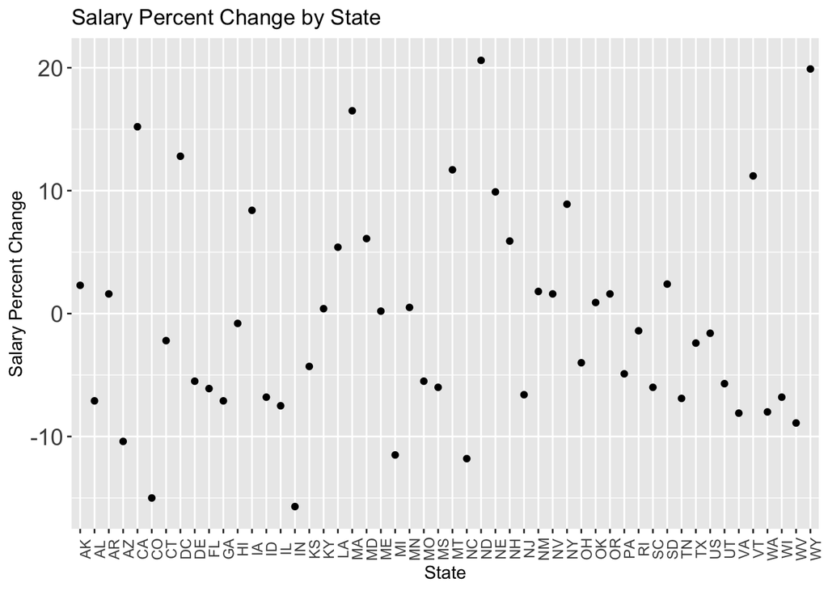

```r
ggplot(education_sum_numbers, aes(State, `Percent_change_1999-2000_to_2016-17`)) + geom_point() +
  labs( x = "State", y = "Salary Percent Change",
  title ="Salary Percent Change by State") +
  theme(axis.text.x = element_text(size = 9, angle=90), axis.text.y = element_text(size=14)) +
  scale_y_continuous()
```

```r
library(caret)
set.seed(125)
sample_selection <- createDataPartition(education_sum_numbers$`Percent_change_1999-2000_to_2016-17`, p = 0.75, list = FALSE)
train <- education_sum_numbers[sample_selection, ]
test <- education_sum_numbers[-sample_selection, ]

train_model <- lm(train, formula =  `Percent_change_1999-2000_to_2016-17` ~ `1970_Less_Than_High_School_Diploma` + `1970_High_School_Diploma_Only` + `1970_Some_College` + `1970_Bachelor_Degree_Or_Higher` + `1980_Less_Than_High_School_Diploma` + `1980_High_School_Diploma_Only` + `1980_Some_College` + `1980_Bachelor_Degree_Or_Higher` + `1990_Less_Than_High_School_Diploma` + `1990_High_School_Diploma_Only` + `1990_Some_College` + `1990_Bachelor_Degree_Or_Higher` + `2000_Less_Than_High_School_Diploma` + `2000_High_School_Diploma_Only` + `2000_Some_College` + `2000_Bachelor_Degree_Or_Higher` + `2013-17_Less_Than_High_School_Diploma` + `2013-17_High_School_Diploma_Only` + `2013-17_Some_College`)

summary(train_model)
```

```
##
## Call:
## lm(formula = `Percent_change_1999-2000_to_2016-17` ~ `1970_Less_Than_High_School_Diploma` +
##     `1970_High_School_Diploma_Only` + `1970_Some_College` + `1970_Bachelor_Degree_Or_Higher` +
##     `1980_Less_Than_High_School_Diploma` + `1980_High_School_Diploma_Only` +
##     `1980_Some_College` + `1980_Bachelor_Degree_Or_Higher` +
##     `1990_Less_Than_High_School_Diploma` + `1990_High_School_Diploma_Only` +
##     `1990_Some_College` + `1990_Bachelor_Degree_Or_Higher` +
##     `2000_Less_Than_High_School_Diploma` + `2000_High_School_Diploma_Only` +
##     `2000_Some_College` + `2000_Bachelor_Degree_Or_Higher` +
##     `2013-17_Less_Than_High_School_Diploma` + `2013-17_High_School_Diploma_Only` +
##     `2013-17_Some_College`, data = train)
##
## Residuals:
##      Min       1Q   Median       3Q      Max
## -11.7916  -3.3625  -0.3327   1.6295  19.4285
##
## Coefficients:
##                                           Estimate Std. Error t value Pr(>|t|)
## (Intercept)                             -4.681e-01  1.404e+00  -0.333   0.7423
## `1970_Less_Than_High_School_Diploma`    -8.301e-05  5.375e-05  -1.544   0.1382
## `1970_High_School_Diploma_Only`          2.156e-05  7.317e-05   0.295   0.7713
## `1970_Some_College`                      7.624e-05  8.847e-05   0.862   0.3990
## `1970_Bachelor_Degree_Or_Higher`         3.746e-05  1.565e-04   0.239   0.8133
## `1980_Less_Than_High_School_Diploma`     7.326e-05  7.220e-05   1.015   0.3224
## `1980_High_School_Diploma_Only`         -3.087e-05  7.624e-05  -0.405   0.6898
## `1980_Some_College`                     -1.137e-04  1.242e-04  -0.915   0.3710
## `1980_Bachelor_Degree_Or_Higher`         1.519e-04  1.657e-04   0.917   0.3703
## `1990_Less_Than_High_School_Diploma`     6.221e-05  9.833e-05   0.633   0.5341
## `1990_High_School_Diploma_Only`          6.037e-05  4.508e-05   1.339   0.1956
## `1990_Some_College`                     -1.526e-04  1.070e-04  -1.427   0.1691
## `1990_Bachelor_Degree_Or_Higher`         3.128e-05  7.011e-05   0.446   0.6602
## `2000_Less_Than_High_School_Diploma`    -9.005e-05  1.051e-04  -0.857   0.4017
## `2000_High_School_Diploma_Only`         -2.698e-05  4.613e-05  -0.585   0.5651
## `2000_Some_College`                      1.970e-04  1.194e-04   1.649   0.1147
## `2000_Bachelor_Degree_Or_Higher`        -8.086e-05  4.381e-05  -1.846   0.0798
## `2013-17_Less_Than_High_School_Diploma`  6.210e-05  5.183e-05   1.198   0.2448
## `2013-17_High_School_Diploma_Only`      -3.220e-05  2.747e-05  -1.172   0.2548
## `2013-17_Some_College`                  -3.456e-05  3.235e-05  -1.068   0.2981
##
```

[output cut: 11 more lines]

```
## `1990_Some_College`
## `1990_Bachelor_Degree_Or_Higher`
## `2000_Less_Than_High_School_Diploma`
## `2000_High_School_Diploma_Only`
## `2000_Some_College`
## `2000_Bachelor_Degree_Or_Higher`        .
## `2013-17_Less_Than_High_School_Diploma`
## `2013-17_High_School_Diploma_Only`
## `2013-17_Some_College`
## ---
## Signif. codes:  0 '***' 0.001 '**' 0.01 '*' 0.05 '.' 0.1 ' ' 1
##
## Residual standard error: 7.599 on 20 degrees of freedom
## Multiple R-squared:  0.5274, Adjusted R-squared:  0.0784
## F-statistic: 1.175 on 19 and 20 DF,  p-value: 0.3614
```

# Summary:

From the results of the summary of the model we can see the the overall p-value of the model is 0.3614. This p-value shows that the number of graduates data is not a very good predictor of the percent change in salary. The p-value is the probability that there is a correlation between the variables by chance. Typically having a p-value of ~ 5% is ideal. Therefore having the p value of 0.3614 shows that this is not the best model. This could show that the number of graduates data does not relate very well how teaching salaries have changed over time.

Now I will use the test data to test the model.

```r
prediction <- train_model %>% predict(test)

R2(prediction, test$`Percent_change_1999-2000_to_2016-17`)
```

```
## [1] 0.002123381
```

```r
MAE(prediction, test$`Percent_change_1999-2000_to_2016-17`)
```

```
## [1] 14.97933
```

```r
RMSE(prediction, test$`Percent_change_1999-2000_to_2016-17`)
```

```
## [1] 16.78241
```

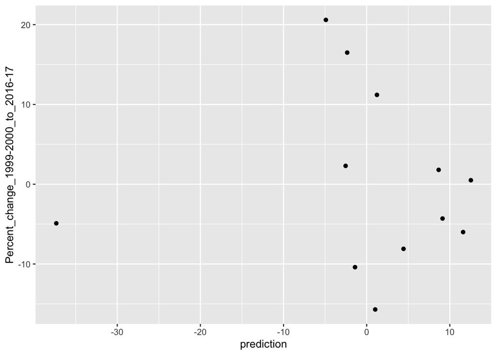

```r
ggplot(test, aes(x = prediction, y = `Percent_change_1999-2000_to_2016-17`)) + geom_point()
```